# CoMMpass spectra outcomes GSEA figure 20221207

```r
library(readr)
library(dplyr)
library(tidyr)
library(fgsea)
library(purrr)
library(ggplot2)
library(ggsci)
library(forcats)
```

## bring in the data

### CoMMpass rotation matrix

```r
cmps_spec_rm <-
  read_csv("~/Documents/stats/survival/commpass_proj/spectra_commpass_product/CoMMpass_inclfollowup_final_SpectraData_20210601/spectra_rotation_matrix-gene_centers-2021-06-01.csv.gz")
colnames(cmps_spec_rm) <- c("gene_id", "mean", paste0("Sp", 1:39))
```

bring in gene annotation to get gene names

```r
gencode_annot <-
  read_csv("~/Documents/stats/survival/commpass_proj/commpass_spectra/Homo_sapiens.GRCh37.74.gtf.flat.csv")
```

```r
gid_names <- gencode_annot %>% distinct(gene_id, .keep_all = T) %>% select(gene_id, gene_name)
```

```r
cmps_spec_rm_wn <- left_join(cmps_spec_rm, gid_names, by="gene_id") %>%
  select(-mean) %>%
  relocate(gene_name)
```

are there any duplicate gene_names?

```r
cmps_spec_rm_wn %>%
    add_count(gene_name) %>%
    filter(n>1) %>%
  select(gene_name, gene_id, n)
```

| gene_name | gene_id | n |
| --- | --- | --- |
| PAGR1 | ENSG00000185928 | 2 |
| PAGR1 | ENSG00000263136 | 2 |

crap, yes there is one, these were apparently combined later. just going to leave them and see how it goes…

### gene sets

minimal description of collections and where to get them:  
https://www.gsea-msigdb.org/gsea/msigdb/collections.jsp

a bit more detail info on collections:  
https://www.gsea-msigdb.org/gsea/msigdb/collection_details.jsp

`hallmark`

```r
hallmark <- gmtPathways("h.all.v7.4.symbols.gmt")
```

this is the `Hallmark` set, which is kind of a meta set derived from multiple other sets in the MSigDB that reduces redundancy  
https://www.cell.com/cell-systems/fulltext/S2405-4712(15)00218-5

`cannonical`

```r
c2_cannonical <- gmtPathways("c2.cp.v7.4.symbols.gmt")
```

this is the `canonical pathways` subset of the `c2` collection:  
https://www.gsea-msigdb.org/gsea/msigdb/genesets.jsp?collection=CP

it includes the `BIOCARTA`, `WIKIPATHWAYS`, `REACTOME`, `KEGG`, and `PID` are three different collections  
BIOCARTA: https://maayanlab.cloud/Harmonizome/dataset/Biocarta+Pathways (seems old)  
WIKIPATHWAYS: https://www.wikipathways.org/index.php/WikiPathways REACTOME: https://reactome.org/ KEGG: Kyoto Encyclopedia of Genes and Genomes: https://www.genome.jp/kegg/  
PID: Pathway Interaction Database: https://pubmed.ncbi.nlm.nih.gov/18832364/ (seems old)

`ontology`

```r
c5_ontology <- gmtPathways("c5.all.v7.4.symbols.gmt")
```

entire `c5` collection described as `ontology gene sets` https://www.gsea-msigdb.org/gsea/msigdb/genesets.jsp?collection=C5  
GO (gene ontology) gene sets: http://amigo.geneontology.org/amigo  
GO:BP (GO biological process, 7481 gene sets)  
GO:CC (GO cellular component, 996 gene sets)  
GO:MF (GO molecular function, 1708 gene sets)  
and  
HPO (Human Phenotype Ontology, 4813 gene sets): https://hpo.jax.org/app/

### CoMMpass spectra associated with survival outcomes

the following spectra are significant in the CoxPH model  
OS: Sp2 + Sp3 + Sp4 + Sp5 + Sp9 + Sp12 + Sp13 + Sp19 + Sp26  
PFS: Sp1 + Sp2 + Sp4 + Sp5 + Sp9 + Sp11 + Sp24 + Sp26 + Sp32  
TTF: Sp1 + Sp2 + Sp4 + Sp5 + Sp9 + Sp10 + Sp18 + Sp24 + Sp31 + Sp32

unique spectra list: Sp1, Sp2, Sp3, Sp4, Sp5, Sp9, Sp10, Sp11, Sp12, Sp13, Sp18, Sp19, Sp24, Sp26, Sp31, Sp32

fgsea needs preranked vector with names where names are gene names

## gather GSEA results

The goal is to automate the GSEA for the spectra above and collect output to make a plot of the padj (or NES)

```r
# calc_cllmap_sp_ffs_uto_sa %>%
#   select(contains("spectrum")) %>%
#   purrr::map_dfr(~tidy(t.test(. ~ calc_cllmap_sp_ffs_uto_sa$hi_mut))) %>%
#   mutate(spectrum=paste0("spectrum",1:19,"_SD")) %>%
#   relocate(spectrum) %>%
#   arrange(p.value)
```

```r
# spectra <- c("Sp1", "Sp2", "Sp3", "Sp4", "Sp5", "Sp9", "Sp10", "Sp11", "Sp12", "Sp13", "Sp18",
#              "Sp19", "Sp24", "Sp26", "Sp31", "Sp32")
```

going with an all spectra plot instead

### Hallmark pathways

```r
gsea_results <- data.frame()
set.seed(5413)
for(s in paste0("Sp", 1:39)){
  nspl <- cmps_spec_rm_wn[,s] %>% pull(s)
  names(nspl) <- cmps_spec_rm_wn$gene_name
  nspl <- sort(nspl, decreasing=T)
  fgsea_hm <- fgsea(pathways = hallmark,
                  stats = nspl,
                  eps=0)
  gsea_results <- bind_rows(gsea_results,
                            fgsea_hm %>% filter(padj<0.000025) %>% arrange(padj) %>% mutate(spectra=s))
}
```

```r
gsea_results_sm <- gsea_results %>% select(spectra, pathway, padj, NES, size, leadingEdge)
gsea_results_sm
```

| spectra | pathway | padj | NES | size | leadingEdge |
| --- | --- | --- | --- | --- | --- |
| Sp1 | HALLMARK_TNFA_SIGNALING_VIA_NFKB | 1.029990e-26 | 3.241113 | 96 |  |
| Sp1 | HALLMARK_OXIDATIVE_PHOSPHORYLATION | 8.979959e-13 | -2.589110 | 136 |  |
| Sp1 | HALLMARK_MYC_TARGETS_V1 | 1.440514e-10 | -2.409729 | 143 |  |
| Sp1 | HALLMARK_APOPTOSIS | 2.220112e-07 | 2.277641 | 85 |  |
| Sp1 | HALLMARK_KRAS_SIGNALING_UP | 7.481089e-07 | 2.382512 | 50 |  |
| Sp1 | HALLMARK_HYPOXIA | 1.217005e-06 | 2.166610 | 93 |  |
| Sp1 | HALLMARK_E2F_TARGETS | 6.446903e-06 | -2.023708 | 125 |  |
| Sp1 | HALLMARK_COMPLEMENT | 2.327762e-05 | 2.088538 | 86 |  |
| Sp2 | HALLMARK_INTERFERON_GAMMA_RESPONSE | 1.387257e-09 | 2.475101 | 105 |  |
| Sp2 | HALLMARK_TNFA_SIGNALING_VIA_NFKB | 2.722036e-06 | 2.172007 | 96 |  |

[output cut: 76 more lines]

## group pathways by general function

```r
sort(unique(gsea_results_sm$pathway))
```

```
 [1] "HALLMARK_ANDROGEN_RESPONSE"         "HALLMARK_APICAL_JUNCTION"           "HALLMARK_APOPTOSIS"
 [4] "HALLMARK_COMPLEMENT"                "HALLMARK_E2F_TARGETS"               "HALLMARK_G2M_CHECKPOINT"
 [7] "HALLMARK_HEME_METABOLISM"           "HALLMARK_HYPOXIA"                   "HALLMARK_IL2_STAT5_SIGNALING"
[10] "HALLMARK_INFLAMMATORY_RESPONSE"     "HALLMARK_INTERFERON_ALPHA_RESPONSE" "HALLMARK_INTERFERON_GAMMA_RESPONSE"
[13] "HALLMARK_KRAS_SIGNALING_UP"         "HALLMARK_MITOTIC_SPINDLE"           "HALLMARK_MTORC1_SIGNALING"
[16] "HALLMARK_MYC_TARGETS_V1"            "HALLMARK_MYC_TARGETS_V2"            "HALLMARK_OXIDATIVE_PHOSPHORYLATION"
[19] "HALLMARK_P53_PATHWAY"               "HALLMARK_TNFA_SIGNALING_VIA_NFKB"   "HALLMARK_UNFOLDED_PROTEIN_RESPONSE"
[22] "HALLMARK_UV_RESPONSE_UP"
```

using categories from table 1 from the Hallmark paper (Liberzon et al 2015, http://dx.doi.org/10.1016/j.cels.2015.12.004)

```r
gsea_results_sm <- gsea_results_sm %>%
  mutate(func_gr=case_when(pathway=="HALLMARK_UV_RESPONSE_UP" ~ "DNA damage",
                           pathway=="HALLMARK_APICAL_JUNCTION" ~ "cellular component",
                           pathway %in% c("HALLMARK_COMPLEMENT","HALLMARK_INTERFERON_ALPHA_RESPONSE",
                                          "HALLMARK_INTERFERON_GAMMA_RESPONSE", "HALLMARK_INFLAMMATORY_RESPONSE"
                                          ) ~ "immune",
                           pathway %in% c("HALLMARK_ANDROGEN_RESPONSE", "HALLMARK_IL2_STAT5_SIGNALING",
                                          "HALLMARK_KRAS_SIGNALING_UP", "HALLMARK_MTORC1_SIGNALING",
                                          "HALLMARK_TNFA_SIGNALING_VIA_NFKB"
                                          ) ~ "signaling",
                           pathway %in% c("HALLMARK_E2F_TARGETS", "HALLMARK_G2M_CHECKPOINT",
                                          "HALLMARK_MYC_TARGETS_V1", "HALLMARK_MYC_TARGETS_V2",
                                          "HALLMARK_P53_PATHWAY", "HALLMARK_MITOTIC_SPINDLE"
                                          ) ~ "proliferation",
                           pathway %in% c("HALLMARK_APOPTOSIS", "HALLMARK_HYPOXIA",
                                          "HALLMARK_UNFOLDED_PROTEIN_RESPONSE") ~ "pathway",
                           pathway %in% c("HALLMARK_OXIDATIVE_PHOSPHORYLATION", "HALLMARK_HEME_METABOLISM") ~ "metabolic"))
gsea_results_sm$func_gr <- factor(gsea_results_sm$func_gr,
                                  levels=c("DNA damage", "cellular component", "immune",
                                           "signaling", "proliferation", "pathway", "metabolic"))
```

```r
gsea_results_sm$pathway <- factor(gsea_results_sm$pathway,
                                  levels=as.character(unique(gsea_results_sm[order(gsea_results_sm$func_gr),]$pathway)))
```

## plot padj with color as sign of NES

```r
gsea_results_plt <- gsea_results_sm %>%
  separate(spectra, into=c(NA,"spnum"), sep=2) %>%
  mutate(spnum=as.numeric(spnum)) %>%
  mutate(siglvl=case_when(padj <= 1e-12 ~ 5,
                          padj > 1e-12 & padj <= 1e-10 ~ 4,
                          padj > 1e-10 & padj <= 1e-8 ~ 3,
                          padj > 1e-8 & padj <= 1e-6 ~ 2,
                          padj > 1e-6 & padj <= 2.5e-5 ~ 1)) %>%
  mutate(siglvl=case_when(NES<0 ~ -siglvl,
                             NES>0 ~ siglvl)) %>%
  mutate(dir=case_when(NES<0 ~ -1,
                       NES>0 ~ 1))
gsea_results_plt$pathway <- gsub("HALLMARK_", "", gsea_results_plt$pathway)
gsea_results_plt$func_gr <- factor(gsea_results_plt$func_gr,
                                  levels=c("immune","signaling","proliferation","DNA damage","pathway","cellular component","metabolic"))
gsea_results_plt$pathway <- factor(gsea_results_plt$pathway,
                                  levels=c("COMPLEMENT","INFLAMMATORY_RESPONSE","INTERFERON_GAMMA_RESPONSE",
                                           "INTERFERON_ALPHA_RESPONSE","IL2_STAT5_SIGNALING","TNFA_SIGNALING_VIA_NFKB",
                                           "ANDROGEN_RESPONSE","MTORC1_SIGNALING","KRAS_SIGNALING_UP","MYC_TARGETS_V2",
                                           "MYC_TARGETS_V1","E2F_TARGETS","G2M_CHECKPOINT","MITOTIC_SPINDLE","P53_PATHWAY",
                                           "UV_RESPONSE_UP","APOPTOSIS","UNFOLDED_PROTEIN_RESPONSE","HYPOXIA","APICAL_JUNCTION",
                                           "OXIDATIVE_PHOSPHORYLATION","HEME_METABOLISM"))
gsea_results_plt <- gsea_results_plt %>%
  mutate(ngenes=paste0("(", size, ")")) %>%
  unite(path_ngenes, pathway, ngenes, sep=" ", remove=F)

gsea_results_plt$path_ngenes <- factor(gsea_results_plt$path_ngenes,
                                  levels=c("COMPLEMENT (86)","INFLAMMATORY_RESPONSE (57)","INTERFERON_GAMMA_RESPONSE (105)",
                                           "INTERFERON_ALPHA_RESPONSE (54)","IL2_STAT5_SIGNALING (83)","TNFA_SIGNALING_VIA_NFKB (96)",
                                           "ANDROGEN_RESPONSE (53)","MTORC1_SIGNALING (143)","KRAS_SIGNALING_UP (50)",
                                           "MYC_TARGETS_V2 (46)", "MYC_TARGETS_V1 (143)","E2F_TARGETS (125)","G2M_CHECKPOINT (123)",
                                           "MITOTIC_SPINDLE (126)","P53_PATHWAY (110)", "UV_RESPONSE_UP (95)","APOPTOSIS (85)",
                                           "UNFOLDED_PROTEIN_RESPONSE (85)","HYPOXIA (93)","APICAL_JUNCTION (67)",
                                           "OXIDATIVE_PHOSPHORYLATION (136)","HEME_METABOLISM (109)"))
gsea_results_plt$dir <- factor(gsea_results_plt$dir)
```

blue is positive, red is negative NES

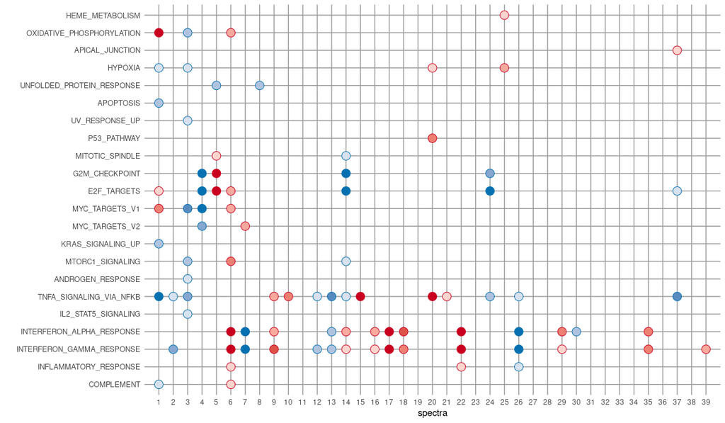

```r
ggplot(gsea_results_plt) +
  geom_point(aes(spnum, pathway, fill = siglvl, colour = dir), shape = 21, size = 4.5) +
  scale_color_manual(values=c("#ca0020","#0571b0")) +
  scale_fill_gradient2(low="#ca0020",mid="white",high="#0571b0",midpoint=0,breaks=5:-5) +
  xlab("spectra") + ylab("") + theme_minimal() +
  scale_x_continuous(expand = c(0,0), limits = c(0,40), breaks=seq(1,39,1)) +
  theme(legend.position="none",
        panel.grid.major = element_line(colour = "gray60"),
        panel.grid.minor = element_blank()) #+
```

```r
  # theme(legend.key.height= unit(1.2, 'cm'),
  #       legend.key.width= unit(1, 'cm'))
```

```r
# ggsave("commpass_gsea_plot_legend_20221218.pdf", device = "pdf", width = 12, height = 7, units = "in", dpi = 320)
```

```r
# ggsave("commpass_gsea_plot_base_20221218.pdf", device = "pdf", width = 12, height = 7, units = "in", dpi = 320)
```

## overlapping leading edge genes

```r
upr_sp <- gsea_results_sm %>% filter(pathway=="HALLMARK_UNFOLDED_PROTEIN_RESPONSE") %>% select(spectra, leadingEdge)
upr_sp
```

| spectra | leadingEdge |
| --- | --- |
| Sp5 |  |
| Sp8 |  |

```r
intersect(unlist(upr_sp[1,2]), unlist(upr_sp[2,2]))
```

```
 [1] "SLC7A5"   "ATF3"     "CHAC1"    "WIPI1"    "PSAT1"    "PDIA5"    "HSPA5"    "SPCS3"    "SRPRB"    "DNAJC3"   "PDIA6"
[12] "DDIT4"    "SERP1"    "CEBPB"    "CALR"     "ASNS"     "EIF4EBP1" "EDEM1"    "HYOU1"    "SLC30A5"  "XPOT"     "SSR1"
[23] "SEC11A"   "EIF4G1"
```

in Sp5 but not Sp8

```r
setdiff(unlist(upr_sp[1,2]), unlist(upr_sp[2,2]))
```

```
 [1] "HERPUD1"  "BAG3"     "HSP90B1"  "WFS1"     "FKBP14"   "ATF4"     "ATP6V0D1" "PREB"     "ATF6"     "ALDH18A1" "SLC1A4"
[12] "SEC31A"   "EDC4"     "ARFGAP1"
```

in Sp8 but not Sp5

```r
setdiff(unlist(upr_sp[2,2]), unlist(upr_sp[1,2]))
```

```
 [1] "ERN1"   "CEBPG"  "EEF2"   "SDAD1"  "EIF2S1" "VEGFA"  "NOP14"  "GEMIN4" "EIF4A2" "EXOSC5" "TTC37"  "DCP1A"  "YWHAZ"  "EXOSC2"
[15] "LSM1"
```

different approach at common genes

```r
Reduce(intersect, upr_sp %>% select(leadingEdge) %>% purrr::flatten())
```

```
 [1] "SLC7A5"   "ATF3"     "CHAC1"    "WIPI1"    "PSAT1"    "PDIA5"    "HSPA5"    "SPCS3"    "SRPRB"    "DNAJC3"   "PDIA6"
[12] "DDIT4"    "SERP1"    "CEBPB"    "CALR"     "ASNS"     "EIF4EBP1" "EDEM1"    "HYOU1"    "SLC30A5"  "XPOT"     "SSR1"
[23] "SEC11A"   "EIF4G1"
```

“HALLMARK_INTERFERON_ALPHA_RESPONSE”

```r
iar_sp <- gsea_results_sm %>% filter(pathway=="HALLMARK_INTERFERON_ALPHA_RESPONSE") %>% select(spectra, leadingEdge)
iar_sp
```

| spectra | leadingEdge |
| --- | --- |
| Sp6 |  |
| Sp7 |  |
| Sp9 |  |
| Sp13 |  |
| Sp14 |  |
| Sp16 |  |
| Sp17 |  |
| Sp18 |  |
| Sp22 |  |
| Sp26 |  |

[output cut: 3 more lines]

common genes

```r
Reduce(intersect, iar_sp %>% select(leadingEdge) %>% purrr::flatten())
```

```
[1] "IFI35"
```

“HALLMARK_INTERFERON_GAMMA_RESPONSE”

```r
igr_sp <- gsea_results_sm %>% filter(pathway=="HALLMARK_INTERFERON_GAMMA_RESPONSE") %>% select(spectra, leadingEdge)
igr_sp
```

| spectra | leadingEdge |
| --- | --- |
| Sp2 |  |
| Sp6 |  |
| Sp7 |  |
| Sp9 |  |
| Sp12 |  |
| Sp13 |  |
| Sp14 |  |
| Sp16 |  |
| Sp17 |  |
| Sp18 |  |

[output cut: 5 more lines]

common genes

```r
Reduce(intersect, igr_sp %>% select(leadingEdge) %>% purrr::flatten())
```

```
character(0)
```

```r
sig_paths <- unique(gsea_results_sm$pathway)
sig_paths
```

```
 [1] HALLMARK_TNFA_SIGNALING_VIA_NFKB   HALLMARK_OXIDATIVE_PHOSPHORYLATION HALLMARK_MYC_TARGETS_V1
 [4] HALLMARK_APOPTOSIS                 HALLMARK_KRAS_SIGNALING_UP         HALLMARK_HYPOXIA
 [7] HALLMARK_E2F_TARGETS               HALLMARK_COMPLEMENT                HALLMARK_INTERFERON_GAMMA_RESPONSE
[10] HALLMARK_MTORC1_SIGNALING          HALLMARK_UV_RESPONSE_UP            HALLMARK_IL2_STAT5_SIGNALING
[13] HALLMARK_ANDROGEN_RESPONSE         HALLMARK_G2M_CHECKPOINT            HALLMARK_MYC_TARGETS_V2
[16] HALLMARK_UNFOLDED_PROTEIN_RESPONSE HALLMARK_MITOTIC_SPINDLE           HALLMARK_INTERFERON_ALPHA_RESPONSE
[19] HALLMARK_INFLAMMATORY_RESPONSE     HALLMARK_P53_PATHWAY               HALLMARK_HEME_METABOLISM
[22] HALLMARK_APICAL_JUNCTION
22 Levels: HALLMARK_UV_RESPONSE_UP HALLMARK_APICAL_JUNCTION HALLMARK_COMPLEMENT ... HALLMARK_HEME_METABOLISM
```

```r
unique_gene_results <- data.frame()
for (p in sig_paths) {
  tempd <- gsea_results_sm %>% filter(pathway==p) %>% select(spectra, leadingEdge)
  temp_sp <- tempd$spectra
  for (s in temp_sp) {
    temp_lel <- list(tempd %>% filter(spectra==s) %>% pull(leadingEdge) %>% unlist(),
                     tempd %>% filter(spectra!=s) %>% pull(leadingEdge) %>% unlist())
    temp_ugl <- Reduce(setdiff, temp_lel)
    unique_gene_results <- bind_rows(unique_gene_results,
                                     data.frame(spectra=s, pathway=p, n_unique_genes=length(temp_ugl),
                                                unique_genes=paste(temp_ugl, collapse = ",")))
  }
}
```

```r
# write_csv(unique_gene_results, "test_unique_gene_summary_20221214.csv")
```

```r
common_gene_results <- data.frame()
for (p in sig_paths) {
  tempd <- gsea_results_sm %>% filter(pathway==p) %>% select(spectra, leadingEdge)
  temp_sp <- tempd$spectra
  temp_cgl <- Reduce(intersect, as.list(tempd$leadingEdge))
  common_gene_results <- bind_rows(common_gene_results,
                                     data.frame(pathway=p, spectra=paste(temp_sp, collapse = ","),
                                                n_common_genes=length(temp_cgl),
                                                common_genes=paste(temp_cgl, collapse = ",")))
}
```

```r
common_gene_results
```

| pathway | spectra | n_common_genes | common_genes |
| --- | --- | --- | --- |
| HALLMARK_TNFA_SIGNALING_VIA_NFKB | Sp1,Sp2,Sp3,Sp9,Sp10,Sp12,Sp13,Sp14,Sp15,Sp20,Sp21,Sp24,Sp26,Sp37 | 0 |  |
| HALLMARK_OXIDATIVE_PHOSPHORYLATION | Sp1,Sp3,Sp6 | 29 | NDUFA8,MRPL35,NDUFB5,MRPL15,MRPS11,COX5A,LDHB,NDUFB6,NDUFB3,ETFA,PDHB,MRPS12,NDUFS4,TIMM10,VDAC1,ATP6V0E1,NDUFB7,COX7C,NDUFAB1,UQCRQ,COX17,COX6B1,MRPL11,LDHA,ATP6V1F,COX5B,CYC1,TOMM22,VDAC3 |
| HALLMARK_MYC_TARGETS_V1 | Sp1,Sp3,Sp4,Sp6 | 14 | C1QBP,NHP2,EIF3J,VDAC1,SNRPD2,PA2G4,LSM7,RAN,RPS5,RPS6,EEF1B2,PSMD14,CYC1,SERBP1 |
| HALLMARK_APOPTOSIS | Sp1 | 38 | LMNA,BMF,GADD45B,DDIT3,RARA,ATF3,BCL2L11,BNIP3L,BTG3,CREBBP,CDKN1A,ROCK1,RELA,CDKN1B,SMAD7,CYLD,HMOX1,PDCD4,IRF1,SLC20A1,BCL10,HSPB1,MCL1,GADD45A,LGALS3,PEA15,JUN,SQSTM1,HMGB2,CDC25B,TSPO,ENO2,RHOB,TI… |
| HALLMARK_KRAS_SIGNALING_UP | Sp1 | 30 | LAPTM5,IL10RA,LCP1,TNFAIP3,PPP1R15A,DUSP6,DNMBP,PTBP2,TRIB1,USP12,CXCR4,MAP3K1,ZNF639,ETV5,HDAC9,LAT2,MMD,GALNT3,EVI5,CCSER2,ID2,CDADC1,BIRC3,RABGAP1L,IKZF1,STRN,VWA5A,NIN,PRDM1,ANKH |
| HALLMARK_HYPOXIA | Sp1,Sp3,Sp20,Sp25 | 3 | TNFAIP3,ATF3,PLIN2 |
| HALLMARK_E2F_TARGETS | Sp1,Sp4,Sp5,Sp6,Sp14,Sp24,Sp37 | 8 | RRM2,MKI67,MCM3,MAD2L1,STMN1,RNASEH2A,MCM2,TACC3 |
| HALLMARK_COMPLEMENT | Sp1,Sp6 | 9 | EHD1,LGMN,DUSP6,IRF1,LGALS3,PLEK,LYN,CALM1,ANXA5 |
| HALLMARK_INTERFERON_GAMMA_RESPONSE | Sp2,Sp6,Sp7,Sp9,Sp12,Sp13,Sp14,Sp16,Sp17,Sp18,Sp22,Sp26,Sp29,Sp35,Sp39 | 0 |  |
| HALLMARK_MTORC1_SIGNALING | Sp3,Sp6,Sp14 | 8 | LDHA,SLC7A5,DDIT4,INSIG1,SLC1A5,SLC6A6,DHCR7,CALR |

[output cut: 12 more lines]

```r
# write_csv(common_gene_results, "test_common_gene_summary_20221214.csv")
```

```r
common_gene_results %>% filter(pathway=="HALLMARK_INTERFERON_GAMMA_RESPONSE" | pathway=="HALLMARK_INTERFERON_ALPHA_RESPONSE")
```

| pathway | spectra | n_common_genes | common_genes |
| --- | --- | --- | --- |
| HALLMARK_INTERFERON_GAMMA_RESPONSE | Sp2,Sp6,Sp7,Sp9,Sp12,Sp13,Sp14,Sp16,Sp17,Sp18,Sp22,Sp26,Sp29,Sp35,Sp39 | 0 |  |
| HALLMARK_INTERFERON_ALPHA_RESPONSE | Sp6,Sp7,Sp9,Sp13,Sp14,Sp16,Sp17,Sp18,Sp22,Sp26,Sp29,Sp30,Sp35 | 1 | IFI35 |

```r
# common_gene_results %>% rowwise() %>% stringr::str_split(common_genes, ",")
```

get common genes back out of comma sep vectors to lists

```r
gene_lists <- sapply(common_gene_results$common_genes, strsplit, split=",", USE.NAMES = F)
names(gene_lists) <- common_gene_results$pathway
```

put in dataframe and make into long format then count

```r
tibble::enframe(gene_lists, name="pathway", value="gene") %>%
  unnest(cols = c(gene)) %>%
  group_by(gene) %>%
  summarise(gene_count=n()) %>%
  filter(gene_count>1) %>%
  arrange(desc(gene_count))
```

| gene | gene_count |
| --- | --- |
| ATF3 | 5 |
| CCND3 | 5 |
| IRF1 | 4 |
| DDIT4 | 3 |
| INSIG1 | 3 |
| RHOB | 3 |
| ADD1 | 2 |
| ASNS | 2 |
| ATP6V1F | 2 |
| B4GALT1 | 2 |

[output cut: 46 more lines]